# HW1

Intermediate Statistics

Frank Edwards

1/25/2019

To compile your RMarkdown document, click the ‘Knit’ button at the top of the script editing pane. This will make an html document that you can open in any web browser (or Word). I recommend directly completing your homework in this RMarkdown document (HW1.Rmd)

*Remember to run install.packages(“tidyverse”) directly on the console (see the console tab on your terminal pane) before proceeding.*

You only have to do this once on your computer. Then make sure to include library(tidyverse) before any other R code in your markdown document. Tidyverse loads the packages readr, dplyr, ggplot2 and a few others into the working environment.

```r
library(tidyverse)
```

## Question 1

For this problem, we will use data built into R. Load the data using the console command data(anscombe).

Describe the relationships between y1 and x1, y2 and x2, y3 and x3, and y4 and x4 in sequence. Construct linear regression models and any descriptive statistics or visuals that you find helpful. Compare results across the y~x pairs. Do you notice anything interesting across your results? If so, describe the implications of your findings.

The general code you will want to use to run a linear model is:

```r
data(anscombe)
model_1<-lm(y1~x1, data = anscombe)
```

Also, explore the data with the summary() and ggplot() functions.

You can embed a scatterplot in RMarkdown with code like this. Note that anything following # is a comment and is not executed by R. We use comments to document our code and make it more clear what we are trying to do. I recommend using comments frequently.

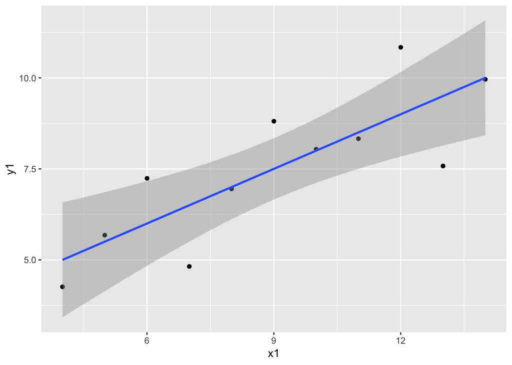

```r
### Plot x1,y1, add an OLS line fit to the data
### Not that I've formatted the code this way to make it readable. It could all be on one line if you wanted
### The line breaks and tabs don't have any inherent meaning in R code.
ggplot(data = anscombe, ### Tell ggplot what data we are using
       aes(x = x1, y = y1)) + ### give ggplot the 'aesthetic' variables we're using
  geom_point() + ### add a scatterplot using the aes() variables
  geom_smooth( ### add a fitted line using the aes() variables
    method = "lm", ### use an OLS method, there are others available
    formula = y~x) ### provide it with a regression formula to estimate
```

**SOLUTION**

I am showing you a solution that relies on loops to accomplish the task. We’ve got four pairs of data that yield identical linear models, but have wildly different distributions. Always plot your data!

```
##
## Call:
## lm(formula = y ~ x, data = new_dat)
##
## Residuals:
##      Min       1Q   Median       3Q      Max
## -1.92127 -0.45577 -0.04136  0.70941  1.83882
##
## Coefficients:
##             Estimate Std. Error t value Pr(>|t|)
## (Intercept)   3.0001     1.1247   2.667  0.02573 *
## x             0.5001     0.1179   4.241  0.00217 **
## ---
## Signif. codes:  0 '***' 0.001 '**' 0.01 '*' 0.05 '.' 0.1 ' ' 1
##
## Residual standard error: 1.237 on 9 degrees of freedom
## Multiple R-squared:  0.6665, Adjusted R-squared:  0.6295
## F-statistic: 17.99 on 1 and 9 DF,  p-value: 0.00217
```

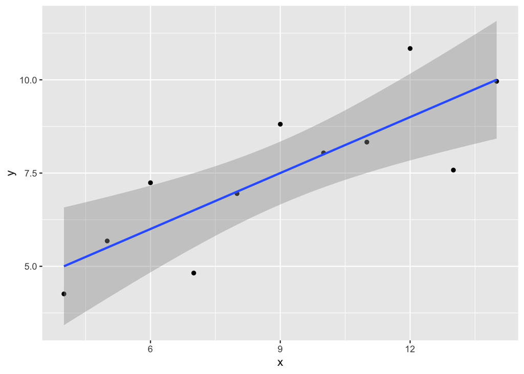

```
##
## Call:
## lm(formula = y ~ x, data = new_dat)
##
## Residuals:
##     Min      1Q  Median      3Q     Max
## -1.9009 -0.7609  0.1291  0.9491  1.2691
##
## Coefficients:
##             Estimate Std. Error t value Pr(>|t|)
## (Intercept)    3.001      1.125   2.667  0.02576 *
## x              0.500      0.118   4.239  0.00218 **
## ---
## Signif. codes:  0 '***' 0.001 '**' 0.01 '*' 0.05 '.' 0.1 ' ' 1
##
## Residual standard error: 1.237 on 9 degrees of freedom
## Multiple R-squared:  0.6662, Adjusted R-squared:  0.6292
## F-statistic: 17.97 on 1 and 9 DF,  p-value: 0.002179
```

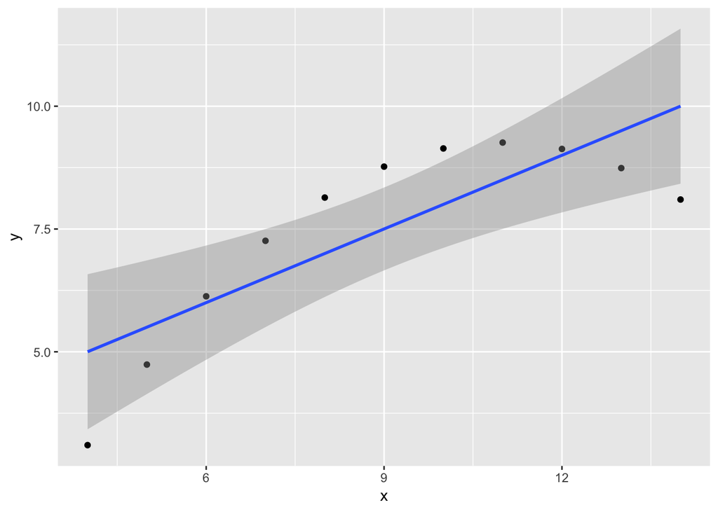

```
##
## Call:
## lm(formula = y ~ x, data = new_dat)
##
## Residuals:
##     Min      1Q  Median      3Q     Max
## -1.1586 -0.6146 -0.2303  0.1540  3.2411
##
## Coefficients:
##             Estimate Std. Error t value Pr(>|t|)
## (Intercept)   3.0025     1.1245   2.670  0.02562 *
## x             0.4997     0.1179   4.239  0.00218 **
## ---
## Signif. codes:  0 '***' 0.001 '**' 0.01 '*' 0.05 '.' 0.1 ' ' 1
##
## Residual standard error: 1.236 on 9 degrees of freedom
## Multiple R-squared:  0.6663, Adjusted R-squared:  0.6292
## F-statistic: 17.97 on 1 and 9 DF,  p-value: 0.002176
```

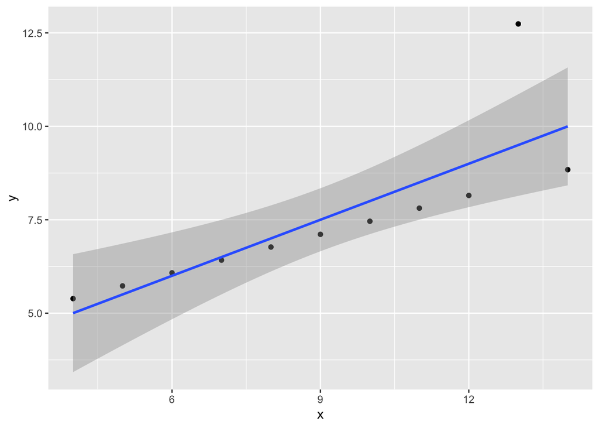

```
##
## Call:
## lm(formula = y ~ x, data = new_dat)
##
## Residuals:
##    Min     1Q Median     3Q    Max
## -1.751 -0.831  0.000  0.809  1.839
##
## Coefficients:
##             Estimate Std. Error t value Pr(>|t|)
## (Intercept)   3.0017     1.1239   2.671  0.02559 *
## x             0.4999     0.1178   4.243  0.00216 **
## ---
## Signif. codes:  0 '***' 0.001 '**' 0.01 '*' 0.05 '.' 0.1 ' ' 1
##
## Residual standard error: 1.236 on 9 degrees of freedom
## Multiple R-squared:  0.6667, Adjusted R-squared:  0.6297
## F-statistic:    18 on 1 and 9 DF,  p-value: 0.002165
```

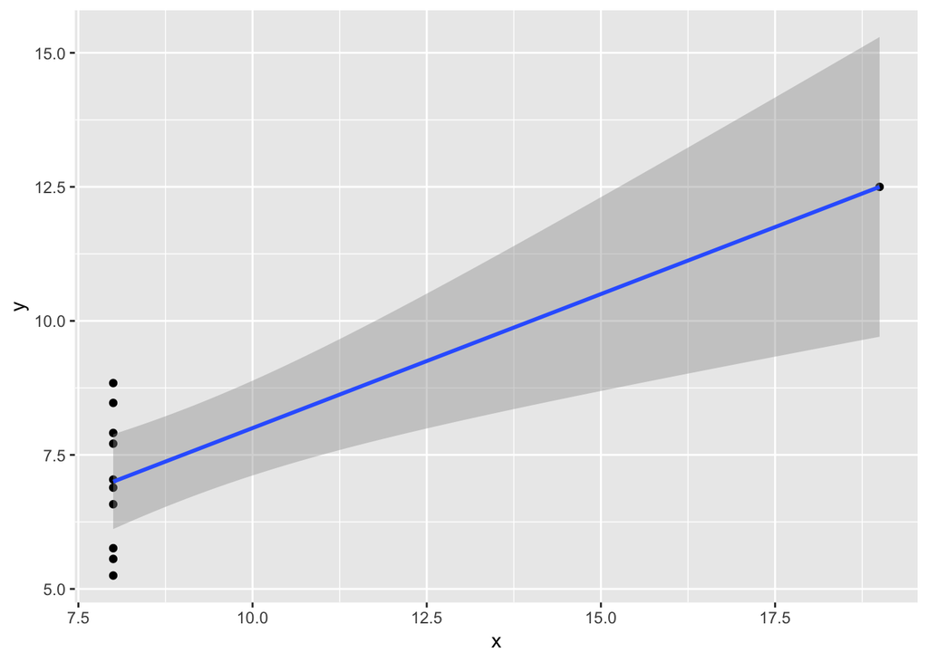

```r
for(i in 1:4){
  new_dat<-data.frame(x = anscombe[,i], y = anscombe[,i+4])
  model<-lm(y~x, data = new_dat)
  print(summary(model))
  print(ggplot(new_dat,
         aes(x = x, y = y)) +
    geom_point() +
    geom_smooth(method = "lm",
                formula = y~x))
}
```

## Question 2

Use the data in revenue_dat.csv in the course repository.

1. Load in the data

```r
### you can read the data directly from the web
cj_budgets<-read_csv("https://github.com/f-edwards/intermediate_stats/raw/master/data/revenue_dat.csv")
### or clone the git repo
### if git is installed, go to your terminal tab in RMarkdown and type
### git clone https://github.com/f-edwards/intermediate_stats.git
```

2. Use the mutate() function in the dplyr package to construct a new variable for property tax revenue per capita called prop_tax_pc using the variables rev_prop_tax and tot_pop.

```r
### general syntax to use mutate() to create new variables
cj_budgets<-cj_budgets%>%
  mutate(temp_variable = 1 + rev_prop_tax / 2)
# any operation on a vector (column) or scalar (single value) works.
# you can use multiple vectors in a mutate() assignment
```

**SOLUTION**

```r
cj_budgets<-cj_budgets%>%
  mutate(prop_tax_pc = rev_prop_tax / pop_tot)
```

3. Transform prop_tax_pc into a binary variable equal to TRUE if property tax revenues per capita are greater than or equal to the median value of the variable, FALSE otherwise

```r
### using >, <, >= or <= returns TRUE or FALSE, and can handle vectors
a<-c(1,2,3)
b<-c(2,1,3)
a>=b
```

```
## [1] FALSE  TRUE  TRUE
```

**SOLUTION**

```r
cj_budgets<-cj_budgets%>%
  mutate(prop_tax_pc = prop_tax_pc>=median(prop_tax_pc))
```

4. Run a linear regression model of the proportion of the population in deep poverty (pop_pct_deep_pov) as a function of property tax revenues per capita (your binary measure).

**SOLUTION**

```r
model1<-lm(pop_pct_deep_pov ~
             prop_tax_pc,
           data = cj_budgets)
```

See code from the lecture slides for an example of this syntax.

5. Add an interaction term. Interact your property tax indicator with the racial composition of the county (pct_blk = pop_blk / pop_tot)

```r
cj_budgets<-cj_budgets%>%
  mutate(pct_blk = pop_blk/pop_tot)

model2<-lm(pop_pct_deep_pov ~
             prop_tax_pc * pct_blk,
           data = cj_budgets)
```

You can add interactions to a model with syntax like this:

lm( y ~ x1 * x2)

6. Display your results

use summary() to show these results. You can also use the tidy() function from library(broom) for a tidier presentation.

**Solution**

```r
library(broom)
tidy(model1)
```

```
## # A tibble: 2 x 5
##   term            estimate std.error statistic  p.value
##   <chr>              <dbl>     <dbl>     <dbl>    <dbl>
## 1 (Intercept)       0.0774  0.000714     108.  0.
## 2 prop_tax_pcTRUE  -0.0170  0.00101      -16.9 6.98e-62
```

```r
tidy(model2)
```

```
## # A tibble: 4 x 5
##   term                    estimate std.error statistic   p.value
##   <chr>                      <dbl>     <dbl>     <dbl>     <dbl>
## 1 (Intercept)              0.0679   0.000773     87.8  0.
## 2 prop_tax_pcTRUE         -0.0171   0.00108     -15.8  8.05e- 55
## 3 pct_blk                  0.0923   0.00422      21.9  1.02e-100
## 4 prop_tax_pcTRUE:pct_blk  0.00810  0.00596       1.36 1.74e-  1
```

## Question 4

Describe and interpret the results from the interaction model. Explain the meaning of the intercept and estimated beta coefficients in the regression model.

**SOLUTION**

Model 1: $\beta_0 =$ 0.077, indicating the exepcted deep poverty rate for a county with below median property tax revenue per capita. $_1 = $ -0.017, the difference in deep poverty rates in counties with at or above median property tax revenue. For a high property tax revenue county, we expect the deep poverty rate to be $\beta_0 + \beta_1$ = 0.06

*Not needed for solution, but interesting*

We can more easily see these results using predictions.

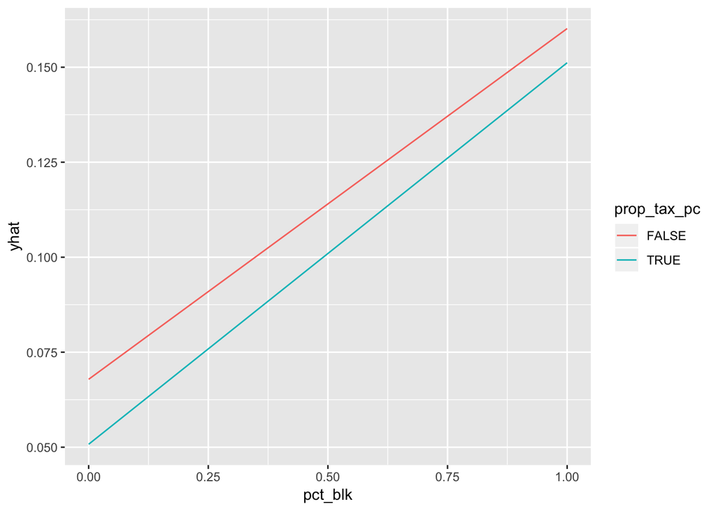

```r
pct_blk<-rep(seq(0,1,length=100),2)
prop_tax_pc<-c(rep(TRUE, 100), rep(FALSE, 100))
fake_data<-data.frame(pct_blk,
                      prop_tax_pc)
fake_data<-fake_data%>%
  mutate(yhat = predict(model2, newdata = fake_data))
ggplot(fake_data,
       aes(x = pct_blk, y = yhat, color = prop_tax_pc)) +
  geom_line()
```

## Question 5

Propose a topic for your final paper. You may use one of the recommended datasets in the syllabus or any other dataset that you have access to. Provide me with a concise research question and a brief statement explaining the theoretical importance of the question.

Don’t select a dataset that requires restricted access if you do not currently have approval for this research. Semesters move fast, and I don’t want you to be delayed by IRB or data archive approval processes.

This proposal should be between 100-200 words.